# Análisis de datos de ultrasecuenciación (PEC 2)

Laura Ramon

Junio 2020

# ABSTRACT

La enfermedad tiroidea autoinmune, la cual incluye diferentes formas clínicas de tiroiditis autoinmune, como la tiroiditis de Hashimoto o la enfermedad de Graves, se caracteriza por la producción de anticuerpos contra al menos uno de los principales autoantígenos específicos de la tiroides, como la tiroglobulina (Tg), la proteína principal del coloide; la tiroperoxidasa (TPO), la enzima que cataliza la organización del yodo, y el receptor de tirotropina (TSH-R).Histológicamente, la TH se caracteriza por una infiltración linfocítica que puede reemplazar progresivamente los folículos tiroideos.Todas las formas se caracterizan patológicamente por la infiltración de células mononucleares hematopoyéticas, principalmente linfocitos, en el intersticio entre los folículos tiroideos, aunque se pueden reconocer características específicas en cada variante.[1][2]

# OBJETIVOS

El objetivo de este estudio es realizar un análisis de datos de ultrasecuenciación, en concreto, de datos de expresión (RNAseq), con la finalidad de observar las diferencias en la expresión génica en diferentes muestras de tejidos de tiroides, con distinto tipo de infiltración.

# MATERIALES Y MÉTODOS

## Materiales

### Datos

Este estudio se aplica en un conjunto de datos publicados en el proyecto GTEx, un repositorio público con datos de diferentes genes de 54 tejidos de más de 1000 individuos, los cuales pueden ser usados para la relización de posteriores estudios de expresión génica.

En este estudio se han escogido 292 muestras de tejido de tiroides, las cuales se dividen en tres grupos según su grado de infiltración linfocitaria:

- **Grupo NIT** (*not infiltrated tissues*): 236 muestras
- **Grupo SFI** (*small focal infiltrates*): 42 muestras
- **Grupo ELI** (*extensive lymphoid infiltrates*): 14 muestras

## Métodos

### Directorio y opciones de trabajo

Se escoge un directorio de trabajo dónde se ubicarán los archivos *targets* y *counts* y dónde se almacenarán los datos resultantes del estudio.

### Obtención de los datos

Los datos expuestos anteriormente son proporcionados por los archivos *targets* y *counts*.

- **Targets**: este archivo contiene toda la información sobre las 292 muestras de tiroides del estudio, como son el nombre de la muestra, el nombre experimento, el grupo, el sexo o el nombre corto.
- **Counts**: este archivo contiene la tabla de conteo de genes de las 292 muestras.

Debido al gran número de muestras, se seleccionan aleatoriamente 10 muestras de cada grupo, quedando el estudio reducido al análisis de 30 muestras en total.

En la siguiente tabla se muestran las muestras seleccionadas del archivo *targets*.

Tabla 1. Información de las 30 muestras obtenidas aleatoriamente del archivo targets

| Experiment | SRA_Sample | Sample_Name | Grupo_analisis | body_site | molecular_data_type | sex | Group | ShortName |
| --- | --- | --- | --- | --- | --- | --- | --- | --- |
| SRX564185 | SRS625665 | GTEX-111YS-0726-SM-5GZY8 | 1 | Thyroid | Allele-Specific Expression | male | NIT | 111YS_NIT |
| SRX617167 | SRS644419 | GTEX-13PL6-1026-SM-5L3E5 | 1 | Thyroid | Allele-Specific Expression | female | NIT | 13PL6_NIT |
| SRX627705 | SRS648114 | GTEX-147GR-0726-SM-5S2PL | 1 | Thyroid | RNA Seq (NGS) | male | NIT | 147GR_NIT |
| SRX631143 | SRS648499 | GTEX-12WSH-0226-SM-5GCOG | 1 | Thyroid | Allele-Specific Expression | male | NIT | 12WSH_NIT |
| SRX571884 | SRS627817 | GTEX-ZYFD-0826-SM-5NQ9A | 1 | Thyroid | Allele-Specific Expression | male | NIT | ZYFD-_NIT |
| SRX603800 | SRS638569 | GTEX-ZPCL-0126-SM-4WWC8 | 1 | Thyroid | Allele-Specific Expression | female | NIT | ZPCL-_NIT |
| SRX629859 | SRS648353 | GTEX-13OVJ-0626-SM-5J2O2 | 1 | Thyroid | Allele-Specific Expression | female | NIT | 13OVJ_NIT |
| SRX634070 | SRS648837 | GTEX-146FR-0326-SM-5SI8U | 1 | Thyroid | Allele-Specific Expression | female | NIT | 146FR_NIT |
| SRX596018 | SRS636565 | GTEX-YB5E-0626-SM-4VDSE | 1 | Thyroid | Allele-Specific Expression | male | NIT | YB5E-_NIT |
| SRX199505 | SRS333210 | GTEX-QDVJ-0226-SM-2I5FV | 1 | Thyroid | Allele-Specific Expression | male | NIT | QDVJ-_NIT |
| SRX567279 | SRS626844 | GTEX-12ZZY-0826-SM-5EQMT | 2 | Thyroid | RNA Seq (NGS) | male | SFI | 12ZZY_SFI |
| SRX578169 | SRS629611 | GTEX-11DXY-0426-SM-5H12R | 2 | Thyroid | RNA Seq (NGS) | male | SFI | 11DXY_SFI |
| SRX605452 | SRS639261 | GTEX-12WSG-0226-SM-5EGIF | 2 | Thyroid | RNA Seq (NGS) | female | SFI | 12WSG_SFI |
| SRX601535 | SRS638117 | GTEX-12ZZX-1226-SM-5EGHS | 2 | Thyroid | RNA Seq (NGS) | female | SFI | 12ZZX_SFI |
| SRX616143 | SRS644194 | GTEX-11TUW-0226-SM-5LU8X | 2 | Thyroid | RNA Seq (NGS) | male | SFI | 11TUW_SFI |
| SRX222167 | SRS389523 | GTEX-TKQ1-0126-SM-33HB3 | 2 | Thyroid | RNA Seq (NGS) | male | SFI | TKQ1-_SFI |
| SRX203696 | SRS374817 | GTEX-RM2N-0526-SM-2TF4N | 2 | Thyroid | RNA Seq (NGS) | male | SFI | RM2N-_SFI |
| SRX597594 | SRS637292 | GTEX-ZLV1-0126-SM-4WWBZ | 2 | Thyroid | Allele-Specific Expression | female | SFI | ZLV1-_SFI |
| SRX199518 | SRS333107 | GTEX-Q2AH-0726-SM-2I3EA | 2 | Thyroid | Allele-Specific Expression | male | SFI | Q2AH-_SFI |
| SRX607261 | SRS639479 | GTEX-12BJ1-0426-SM-5FQSO | 2 | Thyroid | Allele-Specific Expression | male | SFI | 12BJ1_SFI |
| SRX607358 | SRS639491 | GTEX-14AS3-0226-SM-5Q5B6 | 3 | Thyroid | RNA Seq (NGS) | female | ELI | 14AS3_ELI |
| SRX575932 | SRS629299 | GTEX-14ABY-0926-SM-5Q5DY | 3 | Thyroid | Allele-Specific Expression | male | ELI | 14ABY_ELI |
| SRX204036 | SRS374975 | GTEX-R55G-0726-SM-2TC6J | 3 | Thyroid | RNA Seq (NGS) | female | ELI | R55G-_ELI |
| SRX619829 | SRS644736 | GTEX-11XUK-0226-SM-5EQLW | 3 | Thyroid | RNA Seq (NGS) | female | ELI | 11XUK_ELI |
| SRX583148 | SRS631283 | GTEX-YJ89-0726-SM-5P9F7 | 3 | Thyroid | RNA Seq (NGS) | male | ELI | YJ89-_ELI |
| SRX582762 | SRS631169 | GTEX-13NZ9-1126-SM-5MR37 | 3 | Thyroid | RNA Seq (NGS) | male | ELI | 13NZ9_ELI |
| SRX601511 | SRS638114 | GTEX-13QJC-0826-SM-5RQKC | 3 | Thyroid | Allele-Specific Expression | female | ELI | 13QJC_ELI |
| SRX568364 | SRS627095 | GTEX-ZYY3-1926-SM-5GZXS | 3 | Thyroid | Allele-Specific Expression | female | ELI | ZYY3-_ELI |
| SRX615373 | SRS644099 | GTEX-YFC4-2626-SM-5P9FQ | 3 | Thyroid | Allele-Specific Expression | female | ELI | YFC4-_ELI |
| SRX563960 | SRS625636 | GTEX-111VG-0526-SM-5N9BW | 3 | Thyroid | RNA Seq (NGS) | male | ELI | 111VG_ELI |

En el archivo *counts* se observa que el formato de los genes no corresponde exactamente con el formato Ensembl, pues le sobra el punto y número del final. Así pues, se procede a eliminar dicha parte.

```r
counts$X1<-gsub("\\..*", "", counts$X1, fixed = FALSE)
```

A continuación, se "subsetea" el archivo *counts* con las 30 muestras obtenidas anteriormente, de manera que se tendrá la tabla de conteos de sólo estas muestras.

En la siguiente tabla se observan las primeras filas de la tabla de conteos de las 30 muestras.

Tabla 2. Primeras filas de la tabla de conteos de las 30 muestras

|  | GTEX-111YS-0726-SM-5GZY8 | GTEX-13PL6-1026-SM-5L3E5 | GTEX-147GR-0726-SM-5S2PL | GTEX-12WSH-0226-SM-5GCOG | GTEX-ZYFD-0826-SM-5NQ9A | GTEX-ZPCL-0126-SM-4WWC8 | GTEX-13OVJ-0626-SM-5J2O2 | GTEX-146FR-0326-SM-5SI8U | GTEX-YB5E-0626-SM-4VDSE | GTEX-QDVJ-0226-SM-2I5FV | GTEX-12ZZY-0826-SM-5EQMT | GTEX-11DXY-0426-SM-5H12R | GTEX-12WSG-0226-SM-5EGIF | GTEX-12ZZX-1226-SM-5EGHS | GTEX-11TUW-0226-SM-5LU8X | GTEX-TKQ1-0126-SM-33HB3 | GTEX-RM2N-0526-SM-2TF4N | GTEX-ZLV1-0126-SM-4WWBZ | GTEX-Q2AH-0726-SM-2I3EA | GTEX-12BJ1-0426-SM-5FQSO | GTEX-14AS3-0226-SM-5Q5B6 | GTEX-14ABY-0926-SM-5Q5DY | GTEX-R55G-0726-SM-2TC6J | GTEX-11XUK-0226-SM-5EQLW | GTEX-YJ89-0726-SM-5P9F7 | GTEX-13NZ9-1126-SM-5MR37 | GTEX-13QJC-0826-SM-5RQKC | GTEX-ZYY3-1926-SM-5GZXS | GTEX-YFC4-2626-SM-5P9FQ | … |
| --- | --- | --- | --- | --- | --- | --- | --- | --- | --- | --- | --- | --- | --- | --- | --- | --- | --- | --- | --- | --- | --- | --- | --- | --- | --- | --- | --- | --- | --- | --- |
| ENSG00000223972 | 4 | 0 | 2 | 3 | 0 | 1 | 5 | 0 | 3 | 15 | 2 | 0 | 3 | 2 | 4 | 8 | 3 | 2 | 1 | 1 | 0 | 1 | 3 | 0 | 4 | 0 | 0 | 6 | 1 | … |
| ENSG00000227232 | 395 | 561 | 542 | 641 | 643 | 534 | 1307 | 514 | 700 | 944 | 491 | 663 | 369 | 679 | 627 | 1388 | 406 | 689 | 874 | 410 | 834 | 775 | 134 | 419 | 1325 | 1002 | 825 | 1003 | 1472 | … |
| ENSG00000243485 | 2 | 0 | 1 | 0 | 0 | 3 | 4 | 1 | 2 | 10 | 2 | 0 | 1 | 2 | 0 | 1 | 4 | 2 | 8 | 2 | 1 | 2 | 1 | 0 | 1 | 1 | 1 | 1 | 1 | … |
| ENSG00000237613 | 1 | 0 | 0 | 0 | 0 | 0 | 3 | 2 | 3 | 2 | 0 | 0 | 3 | 4 | 1 | 1 | 1 | 4 | 2 | 1 | 1 | 0 | 2 | 1 | 0 | 0 | 0 | 2 | 0 | … |
| ENSG00000268020 | 0 | 0 | 0 | 0 | 0 | 2 | 0 | 1 | 0 | 1 | 0 | 0 | 1 | 0 | 0 | 1 | 0 | 0 | 0 | 0 | 0 | 0 | 1 | 0 | 2 | 0 | 0 | 0 | 0 | … |
| ENSG00000240361 | 1 | 0 | 0 | 0 | 0 | 4 | 1 | 1 | 2 | 4 | 0 | 3 | 2 | 1 | 0 | 0 | 1 | 2 | 1 | 1 | 0 | 0 | 0 | 0 | 1 | 1 | 1 | 1 | 1 | … |

Se obtiene una matriz de conteo, dónde cada fila representa un gen Ensembl (en concreto, hay 56202 genes), cada columna representa una muestra de ARN secuenciada y los valores representan el número de fragmentos asignados al gen respectivo.

A continuación, se construye el objeto *DESeqDataSet* a partir de la matriz de recuentos y la tabla de información de las muestras usando la función *DESeqDataSetFromMatrix()* del paquete *DESeq2*.

```r
if (!requireNamespace("BiocManager", quietly = TRUE))
    install.packages("BiocManager")

BiocManager::install("DESeq2")
```

```r
dds
```

```
## class: DESeqDataSet
## dim: 56202 30
## metadata(1): version
## assays(1): counts
## rownames(56202): ENSG00000223972 ENSG00000227232 ... ENSG00000210195
##   ENSG00000210196
## rowData names(0):
## colnames(30): GTEX-111YS-0726-SM-5GZY8 GTEX-13PL6-1026-SM-5L3E5 ...
##   GTEX-YFC4-2626-SM-5P9FQ GTEX-111VG-0526-SM-5N9BW
## colData names(9): Experiment SRA_Sample ... Group ShortName
```

### Análisis exploratorio y visualización de los datos

**Prefiltrado del conjunto de datos**

En primer lugar, debido a que a la matriz de conteo contiene numerosas filas con valores 0 y otras con pocos fragmentos, se procederá a reducir el tamaño del objeto *DESeqDataSet* eliminando dichas filas, las cuales contienen poca o ninguna información sobre la expresión génica.

Se eliminarán las filas que no contienen recuentos o que tienen un solo recuento en todas las muestras.

Con este paso, se eliminan 12677 filas de genes. Se pasa de tener 56202 filas a tener 43525 filas.

**Transformación estabilizadora de la varianza**

Para poder analizar los datos mediante métodos estadísticos, es importante que éstos tengan un mismo rango de varianza en diferentes rangos de valores medios, es decir, que sean homocedásticos. En el caso de los recuentos de RNA-seq, la varianza se espera que crezca con la media, de manera que se tendrán que realizar transformaciones sobre los datos para estabilizar la varianza. Existen dos métodos para realizar estas transformaciones: *VST* y *rlog*. En este estudio, se realizarán ambos y, posteriormente, se compararán sus resultados.

- VST

El método *VST* se usa para datos binomiales negativos con una tendencia de dispersión media. Es fácil de calcular y es menos sensible a valores atípicos de conteo.

Para ello, se usa la función *vst()* y en ella se especifica que las diferencias entre las muestras no contribuyan a la tendencia media-varianza esperada del experimento.

Tabla 3. Primeras filas y muestras de los datos transformados con el método VST

|  | GTEX-111YS-0726-SM-5GZY8 | GTEX-13PL6-1026-SM-5L3E5 | GTEX-147GR-0726-SM-5S2PL | GTEX-12WSH-0226-SM-5GCOG | GTEX-ZYFD-0826-SM-5NQ9A | GTEX-ZPCL-0126-SM-4WWC8 | GTEX-13OVJ-0626-SM-5J2O2 | GTEX-146FR-0326-SM-5SI8U | GTEX-YB5E-0626-SM-4VDSE | GTEX-QDVJ-0226-SM-2I5FV | GTEX-12ZZY-0826-SM-5EQMT | GTEX-11DXY-0426-SM-5H12R | GTEX-12WSG-0226-SM-5EGIF | GTEX-12ZZX-1226-SM-5EGHS | GTEX-11TUW-0226-SM-5LU8X | GTEX-TKQ1-0126-SM-33HB3 | GTEX-RM2N-0526-SM-2TF4N | GTEX-ZLV1-0126-SM-4WWBZ | GTEX-Q2AH-0726-SM-2I3EA | GTEX-12BJ1-0426-SM-5FQSO | GTEX-14AS3-0226-SM-5Q5B6 | GTEX-14ABY-0926-SM-5Q5DY | GTEX-R55G-0726-SM-2TC6J | GTEX-11XUK-0226-SM-5EQLW | GTEX-YJ89-0726-SM-5P9F7 | GTEX-13NZ9-1126-SM-5MR37 | GTEX-13QJC-0826-SM-5RQKC | GTEX-ZYY3-1926-SM-5GZXS | GTEX-YFC4-2626-SM-5P9FQ | … |
| --- | --- | --- | --- | --- | --- | --- | --- | --- | --- | --- | --- | --- | --- | --- | --- | --- | --- | --- | --- | --- | --- | --- | --- | --- | --- | --- | --- | --- | --- | --- |
| ENSG00000223972 | 4.870790 | 4.164768 | 4.701847 | 4.756204 | 4.164768 | 4.484879 | 4.882393 | 4.164768 | 4.715410 | 5.330534 | 4.662320 | 4.164768 | 4.823614 | 4.699904 | 4.894957 | 4.882612 | 4.768594 | 4.634017 | 4.500409 | 4.516417 | 4.164768 | 4.466902 | 5.195555 | 4.164768 | 4.701623 | 4.164768 | 4.164768 | 5.016995 | 4.421616 | … |
| ENSG00000227232 | 8.870032 | 9.340822 | 9.485550 | 9.427378 | 9.581626 | 8.990699 | 10.252381 | 8.953546 | 9.349777 | 9.667950 | 9.140147 | 9.407222 | 8.975489 | 9.786194 | 9.590873 | 9.682875 | 8.866140 | 9.440610 | 9.794100 | 8.889510 | 9.890942 | 9.338166 | 8.851258 | 8.880011 | 9.761115 | 9.573443 | 9.801205 | 10.119720 | 9.772375 | … |
| ENSG00000243485 | 4.666466 | 4.164768 | 4.545630 | 4.164768 | 4.164768 | 4.716977 | 4.807930 | 4.486559 | 4.615267 | 5.124903 | 4.662320 | 4.164768 | 4.547345 | 4.699904 | 4.164768 | 4.420854 | 4.860350 | 4.634017 | 5.099796 | 4.660859 | 4.520469 | 4.591277 | 4.768224 | 4.164768 | 4.434355 | 4.454338 | 4.511069 | 4.516894 | 4.421616 | … |

En la siguiente tabla del colData (información de las muestras), aparece una nueva columna con los *size factors*.

Tabla 4. Información de las muestras tras la transformación VST

|  | Experiment | SRA_Sample | Sample_Name | Grupo_analisis | body_site | molecular_data_type | sex | Group | ShortName | sizeFactor |
| --- | --- | --- | --- | --- | --- | --- | --- | --- | --- | --- |
| GTEX-111YS-0726-SM-5GZY8 | SRX564185 | SRS625665 | GTEX-111YS-0726-SM-5GZY8 | 1 | Thyroid | Allele-Specific Expression | male | NIT | 111YS_NIT | 0.9128557 |
| GTEX-13PL6-1026-SM-5L3E5 | SRX617167 | SRS644419 | GTEX-13PL6-1026-SM-5L3E5 | 1 | Thyroid | Allele-Specific Expression | female | NIT | 13PL6_NIT | 0.9150795 |
| GTEX-147GR-0726-SM-5S2PL | SRX627705 | SRS648114 | GTEX-147GR-0726-SM-5S2PL | 1 | Thyroid | RNA Seq (NGS) | male | NIT | 147GR_NIT | 0.7953761 |
| GTEX-12WSH-0226-SM-5GCOG | SRX631143 | SRS648499 | GTEX-12WSH-0226-SM-5GCOG | 1 | Thyroid | Allele-Specific Expression | male | NIT | 12WSH_NIT | 0.9814331 |
| GTEX-ZYFD-0826-SM-5NQ9A | SRX571884 | SRS627817 | GTEX-ZYFD-0826-SM-5NQ9A | 1 | Thyroid | Allele-Specific Expression | male | NIT | ZYFD-_NIT | 0.8798887 |
| GTEX-ZPCL-0126-SM-4WWC8 | SRX603800 | SRS638569 | GTEX-ZPCL-0126-SM-4WWC8 | 1 | Thyroid | Allele-Specific Expression | female | NIT | ZPCL-_NIT | 1.1278421 |
| GTEX-13OVJ-0626-SM-5J2O2 | SRX629859 | SRS648353 | GTEX-13OVJ-0626-SM-5J2O2 | 1 | Thyroid | Allele-Specific Expression | female | NIT | 13OVJ_NIT | 1.1037434 |
| GTEX-146FR-0326-SM-5SI8U | SRX634070 | SRS648837 | GTEX-146FR-0326-SM-5SI8U | 1 | Thyroid | Allele-Specific Expression | female | NIT | 146FR_NIT | 1.1160477 |
| GTEX-YB5E-0626-SM-4VDSE | SRX596018 | SRS636565 | GTEX-YB5E-0626-SM-4VDSE | 1 | Thyroid | Allele-Specific Expression | male | NIT | YB5E-_NIT | 1.1343458 |
| GTEX-QDVJ-0226-SM-2I5FV | SRX199505 | SRS333210 | GTEX-QDVJ-0226-SM-2I5FV | 1 | Thyroid | Allele-Specific Expression | male | NIT | QDVJ-_NIT | 1.2133728 |
| GTEX-12ZZY-0826-SM-5EQMT | SRX567279 | SRS626844 | GTEX-12ZZY-0826-SM-5EQMT | 2 | Thyroid | RNA Seq (NGS) | male | SFI | 12ZZY_SFI | 0.9282864 |
| GTEX-11DXY-0426-SM-5H12R | SRX578169 | SRS629611 | GTEX-11DXY-0426-SM-5H12R | 2 | Thyroid | RNA Seq (NGS) | male | SFI | 11DXY_SFI | 1.0301734 |
| GTEX-12WSG-0226-SM-5EGIF | SRX605452 | SRS639261 | GTEX-12WSG-0226-SM-5EGIF | 2 | Thyroid | RNA Seq (NGS) | female | SFI | 12WSG_SFI | 0.7882219 |
| GTEX-12ZZX-1226-SM-5EGHS | SRX601535 | SRS638117 | GTEX-12ZZX-1226-SM-5EGHS | 2 | Thyroid | RNA Seq (NGS) | female | SFI | 12ZZX_SFI | 0.8012304 |
| GTEX-11TUW-0226-SM-5LU8X | SRX616143 | SRS644194 | GTEX-11TUW-0226-SM-5LU8X | 2 | Thyroid | RNA Seq (NGS) | male | SFI | 11TUW_SFI | 0.8522511 |
| GTEX-TKQ1-0126-SM-33HB3 | SRX222167 | SRS389523 | GTEX-TKQ1-0126-SM-33HB3 | 2 | Thyroid | RNA Seq (NGS) | male | SFI | TKQ1-_SFI | 1.7648884 |
| GTEX-RM2N-0526-SM-2TF4N | SRX203696 | SRS374817 | GTEX-RM2N-0526-SM-2TF4N | 2 | Thyroid | RNA Seq (NGS) | male | SFI | RM2N-_SFI | 0.9410142 |
| GTEX-ZLV1-0126-SM-4WWBZ | SRX597594 | SRS637292 | GTEX-ZLV1-0126-SM-4WWBZ | 2 | Thyroid | Allele-Specific Expression | female | SFI | ZLV1-_SFI | 1.0447836 |
| GTEX-Q2AH-0726-SM-2I3EA | SRX199518 | SRS333107 | GTEX-Q2AH-0726-SM-2I3EA | 2 | Thyroid | Allele-Specific Expression | male | SFI | Q2AH-_SFI | 1.0254649 |
| GTEX-12BJ1-0426-SM-5FQSO | SRX607261 | SRS639479 | GTEX-12BJ1-0426-SM-5FQSO | 2 | Thyroid | Allele-Specific Expression | male | SFI | 12BJ1_SFI | 0.9338159 |
| GTEX-14AS3-0226-SM-5Q5B6 | SRX607358 | SRS639491 | GTEX-14AS3-0226-SM-5Q5B6 | 3 | Thyroid | RNA Seq (NGS) | female | ELI | 14AS3_ELI | 0.9125592 |
| GTEX-14ABY-0926-SM-5Q5DY | SRX575932 | SRS629299 | GTEX-14ABY-0926-SM-5Q5DY | 3 | Thyroid | Allele-Specific Expression | male | ELI | 14ABY_ELI | 1.2666096 |
| GTEX-R55G-0726-SM-2TC6J | SRX204036 | SRS374975 | GTEX-R55G-0726-SM-2TC6J | 3 | Thyroid | RNA Seq (NGS) | female | ELI | R55G-_ELI | 0.3140617 |
| GTEX-11XUK-0226-SM-5EQLW | SRX619829 | SRS644736 | GTEX-11XUK-0226-SM-5EQLW | 3 | Thyroid | RNA Seq (NGS) | female | ELI | 11XUK_ELI | 0.9611176 |
| GTEX-YJ89-0726-SM-5P9F7 | SRX583148 | SRS631283 | GTEX-YJ89-0726-SM-5P9F7 | 3 | Thyroid | RNA Seq (NGS) | male | ELI | YJ89-_ELI | 1.5920948 |
| GTEX-13NZ9-1126-SM-5MR37 | SRX582762 | SRS631169 | GTEX-13NZ9-1126-SM-5MR37 | 3 | Thyroid | RNA Seq (NGS) | male | ELI | 13NZ9_ELI | 1.3793234 |
| GTEX-13QJC-0826-SM-5RQKC | SRX601511 | SRS638114 | GTEX-13QJC-0826-SM-5RQKC | 3 | Thyroid | Allele-Specific Expression | female | ELI | 13QJC_ELI | 0.9630229 |
| GTEX-ZYY3-1926-SM-5GZXS | SRX568364 | SRS627095 | GTEX-ZYY3-1926-SM-5GZXS | 3 | Thyroid | Allele-Specific Expression | female | ELI | ZYY3-_ELI | 0.9312752 |
| GTEX-YFC4-2626-SM-5P9FQ | SRX615373 | SRS644099 | GTEX-YFC4-2626-SM-5P9FQ | 3 | Thyroid | Allele-Specific Expression | female | ELI | YFC4-_ELI | 1.7544005 |
| GTEX-111VG-0526-SM-5N9BW | SRX563960 | SRS625636 | GTEX-111VG-0526-SM-5N9BW | 3 | Thyroid | RNA Seq (NGS) | male | ELI | 111VG_ELI | 0.9657102 |

- Rlog

El método *rlog* es un método que funciona bien en grupos pequeños (inferiores a 30). En la tabla se observan las primeras filas y muestras de los datos transformados con este método.

```
## rlog() may take a few minutes with 30 or more samples,
## vst() is a much faster transformation
```

Tabla 5. Primeras filas y muestras de los datos transformados con el método rlog

|  | GTEX-111YS-0726-SM-5GZY8 | GTEX-13PL6-1026-SM-5L3E5 | GTEX-147GR-0726-SM-5S2PL | GTEX-12WSH-0226-SM-5GCOG | GTEX-ZYFD-0826-SM-5NQ9A | GTEX-ZPCL-0126-SM-4WWC8 | GTEX-13OVJ-0626-SM-5J2O2 | GTEX-146FR-0326-SM-5SI8U | GTEX-YB5E-0626-SM-4VDSE | GTEX-QDVJ-0226-SM-2I5FV | GTEX-12ZZY-0826-SM-5EQMT | GTEX-11DXY-0426-SM-5H12R | GTEX-12WSG-0226-SM-5EGIF | GTEX-12ZZX-1226-SM-5EGHS | GTEX-11TUW-0226-SM-5LU8X | GTEX-TKQ1-0126-SM-33HB3 | GTEX-RM2N-0526-SM-2TF4N | GTEX-ZLV1-0126-SM-4WWBZ | GTEX-Q2AH-0726-SM-2I3EA | GTEX-12BJ1-0426-SM-5FQSO | GTEX-14AS3-0226-SM-5Q5B6 | GTEX-14ABY-0926-SM-5Q5DY | GTEX-R55G-0726-SM-2TC6J | GTEX-11XUK-0226-SM-5EQLW | GTEX-YJ89-0726-SM-5P9F7 | GTEX-13NZ9-1126-SM-5MR37 | GTEX-13QJC-0826-SM-5RQKC | GTEX-ZYY3-1926-SM-5GZXS | GTEX-YFC4-2626-SM-5P9FQ | … |
| --- | --- | --- | --- | --- | --- | --- | --- | --- | --- | --- | --- | --- | --- | --- | --- | --- | --- | --- | --- | --- | --- | --- | --- | --- | --- | --- | --- | --- | --- | --- |
| ENSG00000223972 | 1.3316133 | 0.7192651 | 1.1123169 | 1.1835261 | 0.7227967 | 0.8683234 | 1.3544694 | 0.7022112 | 1.1333264 | 1.962633 | 1.0659395 | 0.7089189 | 1.2641480 | 1.1100648 | 1.3607387 | 1.3688864 | 1.1985698 | 1.0320398 | 0.8867531 | 0.9055627 | 0.7195118 | 0.8468188 | 1.6522211 | 0.7149187 | 1.1184090 | 0.6856234 | 0.7147451 | 1.5289975 | 0.7923101 | … |
| ENSG00000227232 | 8.9211254 | 9.2821251 | 9.3937031 | 9.3488295 | 9.4679588 | 9.0131728 | 9.9903162 | 8.9847394 | 9.2889968 | 9.534890 | 9.1278686 | 9.3332843 | 9.0018894 | 9.6264539 | 9.4751031 | 9.5465517 | 8.9181122 | 9.3590404 | 9.6327201 | 8.9359707 | 9.7079563 | 9.2800386 | 8.9095309 | 8.9286776 | 9.6072547 | 9.4617217 | 9.6382100 | 9.8863885 | 9.6160272 | … |
| ENSG00000243485 | 0.7345791 | 0.3967401 | 0.6057353 | 0.3922933 | 0.3992902 | 0.7989284 | 0.9131633 | 0.5448672 | 0.6780972 | 1.333822 | 0.7300514 | 0.3892951 | 0.6074697 | 0.7707443 | 0.4013961 | 0.4762205 | 0.9742734 | 0.6989163 | 1.2915885 | 0.7284538 | 0.5800459 | 0.6512863 | 0.8071175 | 0.3936077 | 0.4902494 | 0.5111390 | 0.5703488 | 0.5763638 | 0.4770099 | … |

A continuación, se realiza un gráfico para comparar ambas transformaciones usando las funciones *log2()*, *vst()* y *rlog()*.

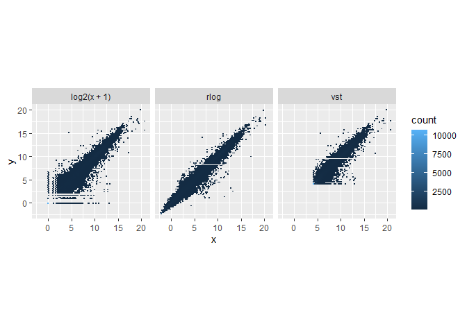

Figura 1. Diagrama de dispersión con las transformaciones log2, rlog y vst

**Distancias entre muestras**

El siguiente paso es evaluar la similitud entre las muestras mediante la distancia que hay entre ellas.

Tabla 6. Distancias entre muestras

| x |
| --- |
| 117.4460 |
| 112.7263 |
| 134.9035 |
| 138.1922 |
| 109.6261 |
| 127.6376 |

Las distancias entre muestras se visualizan mediante un mapa de calor (*heatmap*). Un *heatmap* es una cuadrícula bidimensional, rectangular y de color que muestra datos en forma de matriz rectangular. Por una parte, el color de cada rectángulo está determinado por el valor de la entrada correspondiente en la matriz. Por otro lado, las filas y columnas de la matriz se reorganizan de acuerdo con algún método de agrupamiento jerárquico, de modo que filas y columnas similares se colocan una al lado de la otra, respectivamente.

Para ello, se usará la función *pheatmap()* del paquete *pheatmap*. En esta función se indicará que la matriz de distancia tenga las filas y columnas ordenadas.

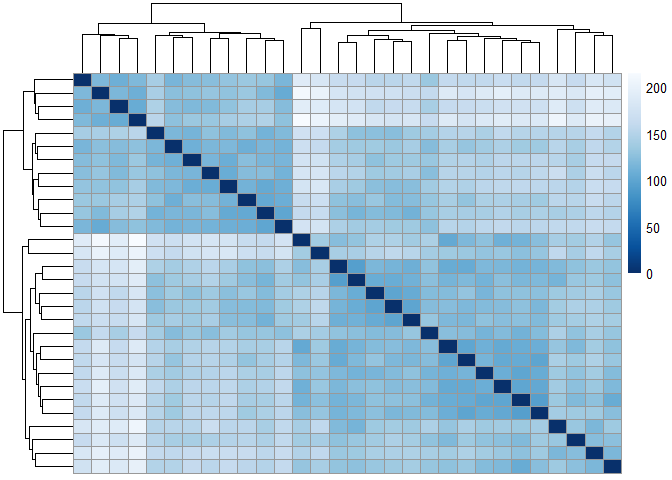

Figura 2. Heatmap sobre la distancia entre muestras

```r
install.packages("pheatmap")
```

*Gráfico PCA*

A continuación, se realizará un gráfico de análisis de componentes principales (PCA) con los datos obtenidos de la transformación VST. Este tipo de gráfico es útil para visualizar el efecto general de las covariables experimentales y los efectos por lotes y se utiliza para reducir conjuntos de datos multidimensionales a dimensiones más bajas para poder realizar el análisis. En este caso, agrupa las muestras por grupos de los genes más significativamente desregulados.

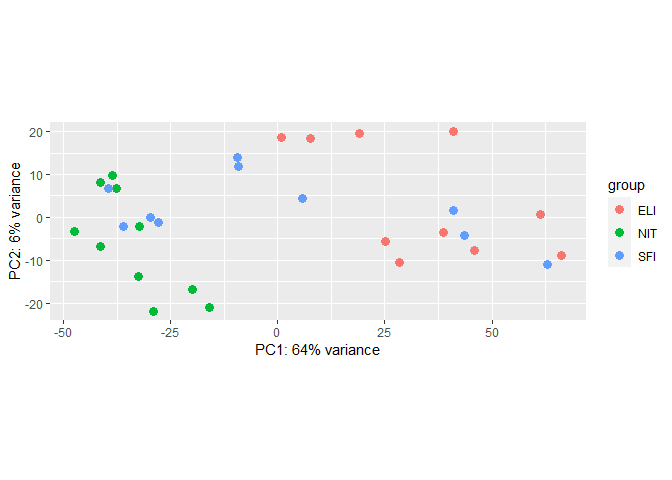

Figura 3. Gráfico PCA con los datos agrupados según el tipo de infiltración

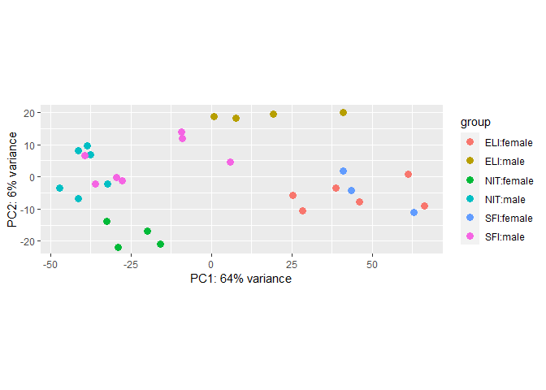

Figura 4. Gráfico PCA con los datos agrupados según el tipo de infiltración y el sexo

Se observa que la primera componente principal explica el 64% de la varianza, mientras que la segunda componente principal explica el 6% de la varianza. Las muestras quedan agrupadas según el tipo de infiltración que presentan, y aún quedan más agrupadas si se tiene en cuenta el sexo del individuo de la muestra.

*Gráfico MDS*

El gráfico MDS (*Multi-dimensional scaling plot*) se realiza cuando se tiene una matriz de distancia. En este caso, se calcula el MDS para las distancias calculadas a partir de los datos calculados con la transformación VST.

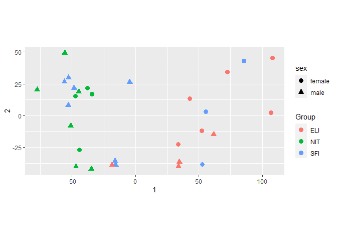

Figura 5. Gráfico MDS con los datos agrupados según el tipo de infiltración y el sexo

**Análisis de expresión diferencial**

Una vez diseñado el modelo experimental con el objeto *DESeqDataSet*, se procede a realizar el análisis de expresión diferencial de los recuentos con la función *DESeq()*.

Al realizar esta operación, se obtiene un *DESeqDataSet* con todos los parámetros ajustados. A continuación, se extaerán las tabla con los resultados de las distintas comparaciones.

*Comparación NIT vs SFI*

Tabla 7. Tabla con los resultados de la comparación NIT vs SFI

|  | baseMean | log2FoldChange | lfcSE | stat | pvalue | padj |
| --- | --- | --- | --- | --- | --- | --- |
| ENSG00000223972 | 2.5370204 | 0.3076156 | 0.7764830 | 0.3961653 | 0.6919831 | 0.8911150 |
| ENSG00000227232 | 674.2513817 | 0.0512003 | 0.1962290 | 0.2609214 | 0.7941531 | 0.9350530 |
| ENSG00000243485 | 1.8052193 | -0.0695605 | 0.6946568 | -0.1001365 | 0.9202360 | 0.9792202 |
| ENSG00000237613 | 1.3000442 | -0.8069776 | 0.9268750 | -0.8706434 | 0.3839489 | NA |
| ENSG00000268020 | 0.3601518 | 0.5411429 | 1.6371007 | 0.3305496 | 0.7409847 | NA |
| ENSG00000240361 | 0.9431724 | 0.0955811 | 0.8197788 | 0.1165938 | 0.9071819 | NA |

*Comparación NIT vs ELI*

```r
resNITvsELI <- results(dds, contrast=c("Group","NIT","ELI"))
```

Tabla 8. Tabla con los resultados de la comparación NIT vs ELI

|  | baseMean | log2FoldChange | lfcSE | stat | pvalue | padj |
| --- | --- | --- | --- | --- | --- | --- |
| ENSG00000223972 | 2.5370204 | 0.8449858 | 0.7993793 | 1.0570524 | 0.2904877 | 0.5032728 |
| ENSG00000227232 | 674.2513817 | -0.1242142 | 0.1961850 | -0.6331484 | 0.5266367 | 0.7141131 |
| ENSG00000243485 | 1.8052193 | 1.1773566 | 0.7691109 | 1.5308020 | 0.1258183 | 0.2930634 |
| ENSG00000237613 | 1.3000442 | 0.6659683 | 1.0145388 | 0.6564247 | 0.5115509 | 0.7032657 |
| ENSG00000268020 | 0.3601518 | 0.0299730 | 1.6292218 | 0.0183971 | 0.9853221 | NA |
| ENSG00000240361 | 0.9431724 | 1.1122321 | 0.9009399 | 1.2345242 | 0.2170077 | NA |

*Comparación SFI vs ELI*

```r
resSFIvsELI <- results(dds, contrast=c("Group","SFI","ELI"))
```

Tabla 9. Tabla con los resultados de la comparación SFI vs ELI

|  | baseMean | log2FoldChange | lfcSE | stat | pvalue | padj |
| --- | --- | --- | --- | --- | --- | --- |
| ENSG00000223972 | 2.5370204 | 0.5373702 | 0.8109319 | 0.6626576 | 0.5075498 | NA |
| ENSG00000227232 | 674.2513817 | -0.1754146 | 0.1962448 | -0.8938559 | 0.3713990 | 0.6314542 |
| ENSG00000243485 | 1.8052193 | 1.2469171 | 0.7679311 | 1.6237357 | 0.1044322 | NA |
| ENSG00000237613 | 1.3000442 | 1.4729459 | 0.9732648 | 1.5134071 | 0.1301763 | NA |
| ENSG00000268020 | 0.3601518 | -0.5111699 | 1.6292218 | -0.3137510 | 0.7537102 | NA |
| ENSG00000240361 | 0.9431724 | 1.0166510 | 0.9098718 | 1.1173563 | 0.2638420 | NA |

A continuación, se extrae la información de las columnas de los dataframe obtenidos.

```r
mcols(resNITvsSFI, use.names = TRUE)
```

```
## DataFrame with 6 rows and 2 columns
##                        type                               description
##                 <character>                               <character>
## baseMean       intermediate mean of normalized counts for all samples
## log2FoldChange      results  log2 fold change (MLE): Group NIT vs SFI
## lfcSE               results          standard error: Group NIT vs SFI
## stat                results          Wald statistic: Group NIT vs SFI
## pvalue              results       Wald test p-value: Group NIT vs SFI
## padj                results                      BH adjusted p-values
```

```r
mcols(resNITvsELI, use.names = TRUE)
```

```
## DataFrame with 6 rows and 2 columns
##                        type                               description
##                 <character>                               <character>
## baseMean       intermediate mean of normalized counts for all samples
## log2FoldChange      results  log2 fold change (MLE): Group NIT vs ELI
## lfcSE               results          standard error: Group NIT vs ELI
## stat                results          Wald statistic: Group NIT vs ELI
## pvalue              results       Wald test p-value: Group NIT vs ELI
## padj                results                      BH adjusted p-values
```

```r
mcols(resSFIvsELI, use.names = TRUE)
```

```
## DataFrame with 6 rows and 2 columns
##                        type                               description
##                 <character>                               <character>
## baseMean       intermediate mean of normalized counts for all samples
## log2FoldChange      results  log2 fold change (MLE): Group SFI vs ELI
## lfcSE               results          standard error: Group SFI vs ELI
## stat                results          Wald statistic: Group SFI vs ELI
## pvalue              results       Wald test p-value: Group SFI vs ELI
## padj                results                      BH adjusted p-values
```

También se pueden resumir los resultados con la función *summary()*.

```r
summary(resNITvsSFI)
```

```
##
## out of 43522 with nonzero total read count
## adjusted p-value < 0.1
## LFC > 0 (up)       : 430, 0.99%
## LFC < 0 (down)     : 1210, 2.8%
## outliers [1]       : 0, 0%
## low counts [2]     : 14348, 33%
## (mean count < 1)
## [1] see 'cooksCutoff' argument of ?results
## [2] see 'independentFiltering' argument of ?results
```

```r
summary(resNITvsELI)
```

```
##
## out of 43522 with nonzero total read count
## adjusted p-value < 0.1
## LFC > 0 (up)       : 3747, 8.6%
## LFC < 0 (down)     : 4810, 11%
## outliers [1]       : 0, 0%
## low counts [2]     : 12660, 29%
## (mean count < 1)
## [1] see 'cooksCutoff' argument of ?results
## [2] see 'independentFiltering' argument of ?results
```

```r
summary(resSFIvsELI)
```

```
##
## out of 43522 with nonzero total read count
## adjusted p-value < 0.1
## LFC > 0 (up)       : 1180, 2.7%
## LFC < 0 (down)     : 1749, 4%
## outliers [1]       : 0, 0%
## low counts [2]     : 18566, 43%
## (mean count < 4)
## [1] see 'cooksCutoff' argument of ?results
## [2] see 'independentFiltering' argument of ?results
```

Para considerar de manera más estricta qué conjuntos de genes son significativos, se pueden aplicar dos métodos: bajar el umbral de la tasa de descubrimiento falso o elevar el umbral de cambio de pliegue log2.

Si se baja el umbral de la tasa de descubrimiento falso:

```
##
## FALSE  TRUE
## 23455  1504
```

Si se eleva el umbral de cambio de pliegue log2:

```
##
## FALSE
## 43522
```

Si se considera que el 10% son falsos positivos, todos los genes con un valor p ajustado por debajo del 10% (0.1) serán considerados positivos.

```
## [1] 1640
```

- En la comparación NIT vs SFI hay 1640 genes significativos.

```
## [1] 8557
```

- En la comparación NIT vs ELI hay 8557 genes significativos.

```
## [1] 2929
```

- En la comparación SFI vs ELI hay 2929 genes significativos.

A continuación, se seleccionan los genes significativos de la tabla de resultados y luego se clasifican según la estimación *log2 fold change* para obtener los genes significativos con una *down-regulation* más fuerte en cada comparación.

*Comparación NIT vs SFI*

```r
resSig1 <- subset(resNITvsSFI, padj < 0.1)
```

Tabla 10. Tabla con los genes significativos con una down-regulation más fuerte en la comparación NIT vs SFI

|  | baseMean | log2FoldChange | lfcSE | stat | pvalue | padj |
| --- | --- | --- | --- | --- | --- | --- |
| ENSG00000235896 | 63.62562 | -8.062218 | 1.380120 | -5.841680 | 0e+00 | 1.40e-06 |
| ENSG00000259337 | 21.98620 | -7.878671 | 1.466346 | -5.372996 | 1e-07 | 1.45e-05 |
| ENSG00000211937 | 1542.11673 | -7.844031 | 1.091859 | -7.184107 | 0e+00 | 0.00e+00 |
| ENSG00000259261 | 462.32095 | -7.843819 | 1.161095 | -6.755536 | 0e+00 | 0.00e+00 |
| ENSG00000211904 | 172.21397 | -7.840077 | 1.188928 | -6.594243 | 0e+00 | 0.00e+00 |
| ENSG00000211663 | 2334.94869 | -7.727939 | 1.007371 | -7.671393 | 0e+00 | 0.00e+00 |

*Comparación NIT vs ELI*

```r
resSig2 <- subset(resNITvsELI, padj < 0.1)
```

Tabla 11. Tabla con los genes significativos con una down-regulation más fuerte en la comparación NIT vs ELI

|  | baseMean | log2FoldChange | lfcSE | stat | pvalue | padj |
| --- | --- | --- | --- | --- | --- | --- |
| ENSG00000100721 | 290.01738 | -9.997039 | 1.3637395 | -7.330608 | 0 | 0e+00 |
| ENSG00000170054 | 38.16571 | -9.224421 | 1.6261269 | -5.672633 | 0 | 9e-07 |
| ENSG00000271046 | 41.02856 | -9.145022 | 1.5760499 | -5.802495 | 0 | 5e-07 |
| ENSG00000211970 | 287.70474 | -9.091330 | 1.0556042 | -8.612443 | 0 | 0e+00 |
| ENSG00000242580 | 43.02808 | -8.982867 | 1.2302809 | -7.301476 | 0 | 0e+00 |
| ENSG00000132185 | 286.02504 | -8.684336 | 0.9859239 | -8.808323 | 0 | 0e+00 |

*Comparación SFI vs ELI*

```r
resSig3 <- subset(resSFIvsELI, padj < 0.1)
```

Tabla 12. Tabla con los genes significativos con una down-regulation más fuerte en la comparación SFI vs ELI

|  | baseMean | log2FoldChange | lfcSE | stat | pvalue | padj |
| --- | --- | --- | --- | --- | --- | --- |
| ENSG00000150165 | 5.278010 | -4.764585 | 1.0594034 | -4.497423 | 0.0000069 | 0.0027689 |
| ENSG00000226423 | 5.009453 | -4.757803 | 0.9549884 | -4.982053 | 0.0000006 | 0.0010085 |
| ENSG00000170054 | 38.165706 | -4.304915 | 1.5056927 | -2.859093 | 0.0042485 | 0.0603395 |
| ENSG00000104921 | 303.924552 | -4.124346 | 0.8183485 | -5.039840 | 0.0000005 | 0.0009691 |
| ENSG00000162897 | 6.489592 | -4.097623 | 1.1416549 | -3.589196 | 0.0003317 | 0.0164264 |
| ENSG00000181617 | 237.622117 | -4.009647 | 1.5131821 | -2.649811 | 0.0080537 | 0.0828680 |

Posteriormente, se realiza el mismo paso pero con los genes significativos con una *up-regulation* más fuerte.

*Comparación NIT vs SFI*

Tabla 13. Tabla con los genes significativos con una up-regulation más fuerte en la comparación NIT vs SFI

|  | baseMean | log2FoldChange | lfcSE | stat | pvalue | padj |
| --- | --- | --- | --- | --- | --- | --- |
| ENSG00000169717 | 2.972250 | 4.860024 | 1.5193571 | 3.198737 | 0.0013803 | 0.0444028 |
| ENSG00000177938 | 3.534959 | 4.187357 | 1.3048810 | 3.208995 | 0.0013320 | 0.0436671 |
| ENSG00000206177 | 16.563578 | 4.178525 | 1.0277635 | 4.065648 | 0.0000479 | 0.0040010 |
| ENSG00000163705 | 1.604478 | 4.093177 | 1.3951732 | 2.933813 | 0.0033483 | 0.0747580 |
| ENSG00000174015 | 2.575094 | 3.658026 | 1.1218858 | 3.260605 | 0.0011117 | 0.0389874 |
| ENSG00000188536 | 7291.456716 | 3.319481 | 0.8559773 | 3.878002 | 0.0001053 | 0.0073867 |

*Comparación NIT vs ELI*

Tabla 14. Tabla con los genes significativos con una up-regulation más fuerte en la comparación NIT vs ELI

|  | baseMean | log2FoldChange | lfcSE | stat | pvalue | padj |
| --- | --- | --- | --- | --- | --- | --- |
| ENSG00000079689 | 104.382283 | 5.957084 | 0.8902853 | 6.691208 | 0.0000000 | 0.0000000 |
| ENSG00000110680 | 570.381075 | 5.388099 | 1.1764928 | 4.579797 | 0.0000047 | 0.0001136 |
| ENSG00000235559 | 3.531598 | 4.638609 | 1.1129877 | 4.167709 | 0.0000308 | 0.0005335 |
| ENSG00000135346 | 20.793679 | 4.310212 | 1.5343426 | 2.809159 | 0.0049671 | 0.0275787 |
| ENSG00000233491 | 3.325074 | 3.872155 | 1.2525508 | 3.091416 | 0.0019920 | 0.0137334 |
| ENSG00000250606 | 80.323425 | 3.857966 | 1.1954447 | 3.227222 | 0.0012500 | 0.0096211 |

*Comparación SFI vs ELI*

Tabla 15. Tabla con los genes significativos con una up-regulation más fuerte en la comparación SFI vs ELI

|  | baseMean | log2FoldChange | lfcSE | stat | pvalue | padj |
| --- | --- | --- | --- | --- | --- | --- |
| ENSG00000079689 | 104.382283 | 4.129540 | 0.8915829 | 4.631695 | 0.0000036 | 0.0019369 |
| ENSG00000250033 | 38.855495 | 4.026567 | 0.7749596 | 5.195842 | 0.0000002 | 0.0005652 |
| ENSG00000204787 | 7.373643 | 3.841759 | 1.3554980 | 2.834205 | 0.0045940 | 0.0628970 |
| ENSG00000151012 | 1459.653886 | 3.745059 | 0.6254292 | 5.987982 | 0.0000000 | 0.0000332 |
| ENSG00000110680 | 570.381075 | 3.503782 | 1.1766822 | 2.977679 | 0.0029044 | 0.0488549 |
| ENSG00000158955 | 11.527302 | 3.495000 | 0.6551914 | 5.334319 | 0.0000001 | 0.0003989 |

**Gráficos de los resultados**

*Gráfico de recuentos*

Para visualizar los recuentos de un gen en particular se usará la función *plotCounts()* que toma como argumentos el *DESeqDataSet*, el nombre de un gen y el grupo sobre el cual trazar los recuentos.

```r
install.packages("ggbeeswarm")
```

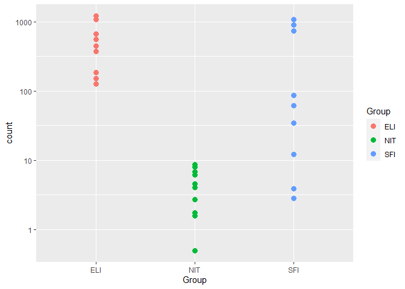

Figura 6. Gráfico de los conteos en las distintas muestras del gen ENSG00000231486

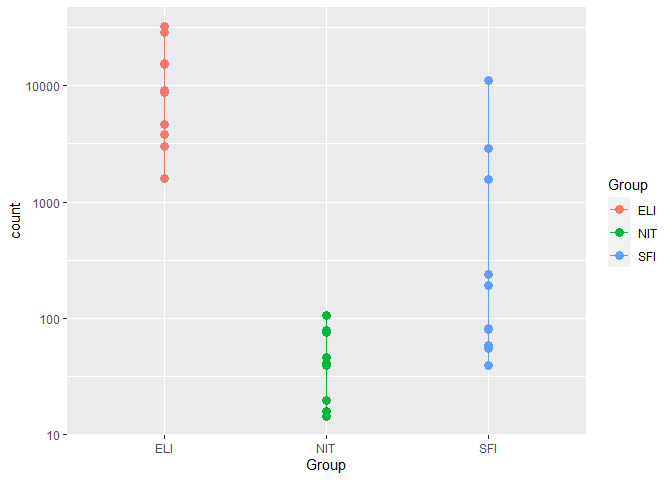

Figura 7. Gráfico de los conteos en las distintas muestras del gen ENSG00000156738

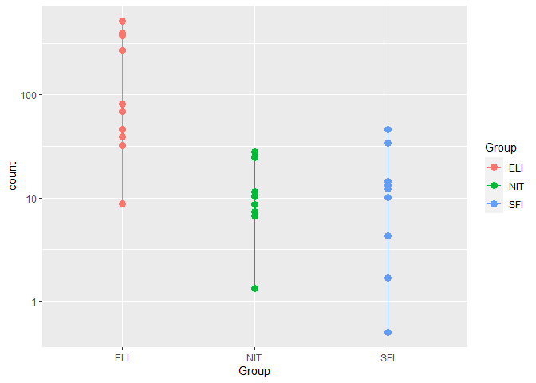

Figura 8. Gráfico de los conteos en las distintas muestras del gen ENSG00000230937

*Diagrama MA*

Un diagrama MA proporciona una visión general sobre la distribución de los coeficientes estimados en el modelo, como las comparaciones de interés, en todos los genes.

Antes de realizar el diagrama MA, se utiliza la función *lfcShrink()* para reducir los *log2 fold changes* para la comparación de muestras entre grupos. Se usará el método *apeglm* para reducir los coeficientes, lo cual reducirá las estimaciones LFC de ruido al tiempo que dará estimaciones de LFC de bajo sesgo para grandes diferencias. A continuación, con la función *resultsNames()* se obtendrán los nombres de los efectos estimados (coeficientes) del modelo.

```r
if (!requireNamespace("BiocManager", quietly = TRUE))
    install.packages("BiocManager")

BiocManager::install("apeglm")
```

Los coeficientes obtenidos son "Group_NIT_vs_ELI" y "Group_SFI_vs_ELI".

Con estos dos coeficientes, se aplica la función *lfcShrink()* con el tipo *apeglm* y se realiza el diagrama MA.

```
## using 'apeglm' for LFC shrinkage. If used in published research, please cite:
##     Zhu, A., Ibrahim, J.G., Love, M.I. (2018) Heavy-tailed prior distributions for
##     sequence count data: removing the noise and preserving large differences.
##     Bioinformatics. https://doi.org/10.1093/bioinformatics/bty895
```

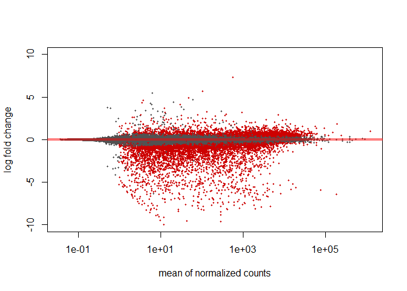

Figura 9. Diagrama MA de la comparación NIT vs ELI

```
## using 'apeglm' for LFC shrinkage. If used in published research, please cite:
##     Zhu, A., Ibrahim, J.G., Love, M.I. (2018) Heavy-tailed prior distributions for
##     sequence count data: removing the noise and preserving large differences.
##     Bioinformatics. https://doi.org/10.1093/bioinformatics/bty895
```

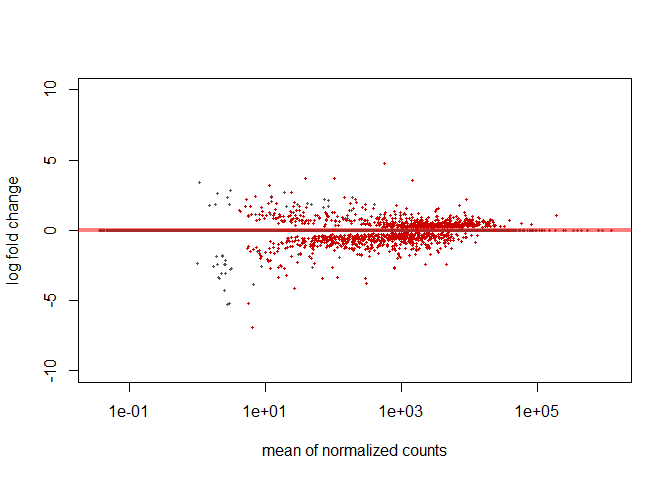

Figura 10. Diagrama MA de la comparación SFI vs ELI

En el diagrama MA, los genes con niveles de expresión similares entre dos grupos se muestran alrededor de la línea horizontal y = 0. Se observa que entre los grupos SFI y ELI existen más genes con niveles de expresión génica similares que entre los grupos NIT y ELI, ya que no hay tanta dispersión.

*Agrupación de genes*

A continuación, se agrupan los genes más variables, es decir, aquellos que tienen una varianza mayor entre las muestras. En este caso se seleccionarán los 20 más variables. Se utilizará la función *pheatmap()* y los datos obtenidos mediante el método VST.

```r
install.packages("pheatmap")
```

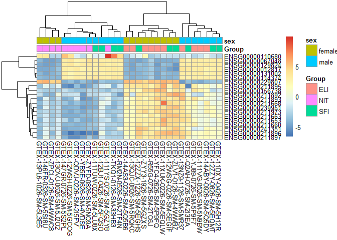

Figura 11. Gráfico de agrupación de genes

```r
topVarGenes <- head(order(rowVars(assay(vsd)), decreasing = TRUE), 20)
mat  <- assay(vsd)[topVarGenes, ]
mat  <- mat - rowMeans(mat)
anno <- as.data.frame(colData(vsd)[, c("Group","sex")])
pheatmap(mat, annotation_col = anno)
```

**Anotación y exportación de los datos**

Los genes aportados por las tablas sólo contienen los ID de los genes de Ensembl, pero para mejorar la interpretación se requiere saber de qué genes se trata y así tener más información. Para ello, se usará el paquete de anotación correspondiente de Bioconductor.

Se puede usar la función *mapIds()* para agregar columnas individuales a la tabla de resultados. Se proporcionan los nombres de la fila de la tabla de resultados en *keys* y se especifica que *keytype* sea *ENSEMBL*. El argumento de la columna le dice a la función qué información se quiere, y el argumento *multiVals* le dice qué debe hacer si hay múltiples valores posibles para un solo valor de entrada. En este caso, se le pide que devuelva el primero que hay en la base de datos.

Comparación NIT vs SFI

Tabla 16. Tabla con la anotación de genes del resultado en la comparación NIT vs SFI

|  | baseMean | log2FoldChange | lfcSE | stat | pvalue | padj | symbol | entrez |
| --- | --- | --- | --- | --- | --- | --- | --- | --- |
| ENSG00000170476 | 1530.2807 | -5.975621 | 0.7389720 | -8.086397 | 0 | 0 | MZB1 | 51237 |
| ENSG00000231486 | 279.9629 | -6.191089 | 0.7708354 | -8.031660 | 0 | 0 | NA | NA |
| ENSG00000211956 | 885.6381 | -6.865983 | 0.8764679 | -7.833696 | 0 | 0 | NA | NA |
| ENSG00000211896 | 184576.2358 | -6.793877 | 0.8698833 | -7.810102 | 0 | 0 | NA | NA |
| ENSG00000211594 | 3131.2538 | -6.685805 | 0.8589383 | -7.783802 | 0 | 0 | NA | NA |
| ENSG00000211973 | 2840.3250 | -7.288705 | 0.9374451 | -7.775074 | 0 | 0 | NA | NA |

Comparación NIT vs ELI

Tabla 17. Tabla con la anotación de genes del resultado en la comparación NIT vs ELI

|  | baseMean | log2FoldChange | lfcSE | stat | pvalue | padj | symbol | entrez |
| --- | --- | --- | --- | --- | --- | --- | --- | --- |
| ENSG00000156738 | 4635.7398 | -8.020560 | 0.7402675 | -10.834678 | 0 | 0 | MS4A1 | 931 |
| ENSG00000167483 | 793.8847 | -7.200773 | 0.7016028 | -10.263319 | 0 | 0 | NIBAN3 | 199786 |
| ENSG00000105369 | 1864.0050 | -7.888422 | 0.8252116 | -9.559272 | 0 | 0 | CD79A | 973 |
| ENSG00000143297 | 1697.7368 | -6.880869 | 0.7285449 | -9.444674 | 0 | 0 | FCRL5 | 83416 |
| ENSG00000035720 | 153.0429 | -7.153203 | 0.7587627 | -9.427457 | 0 | 0 | STAP1 | 26228 |
| ENSG00000177455 | 990.3128 | -7.848321 | 0.8421592 | -9.319284 | 0 | 0 | CD19 | 930 |

Comparación SFI vs ELI

Tabla 18. Tabla con la anotación de genes del resultado en la comparación SFI vs ELI

|  | baseMean | log2FoldChange | lfcSE | stat | pvalue | padj | symbol | entrez |
| --- | --- | --- | --- | --- | --- | --- | --- | --- |
| ENSG00000151012 | 1459.65389 | 3.745059 | 0.6254292 | 5.987982 | 0e+00 | 0.0000332 | SLC7A11 | 23657 |
| ENSG00000230937 | 70.43382 | -3.672490 | 0.6229252 | -5.895556 | 0e+00 | 0.0000332 | MIR205HG | 642587 |
| ENSG00000233355 | 295.97793 | -3.636569 | 0.6179812 | -5.884595 | 0e+00 | 0.0000332 | CHRM3-AS2 | 100506915 |
| ENSG00000231360 | 23.33636 | -4.007508 | 0.7470257 | -5.364619 | 1e-07 | 0.0003989 | NA | NA |
| ENSG00000170486 | 89.63056 | -3.798821 | 0.7120561 | -5.335003 | 1e-07 | 0.0003989 | KRT72 | 140807 |
| ENSG00000158955 | 11.52730 | 3.495000 | 0.6551914 | 5.334319 | 1e-07 | 0.0003989 | WNT9B | 7484 |

**Exportar resultados**

Finalmente, se guardan los resultados en un archivo *.csv*.

# RESULTADOS

El análisis de ultrasecuenciación realizado sobre 30 muestras y un *DESeqDataSet* de 43525 tránscritos, se obtienen los siguientes resultados en las siguientes comparaciones:

**Comparación NIT vs SFI**

En esta comparación se observa:

- LFC > 0 (up): 430 genes (0.99%)
- LFC < 0 (down): 1210 genes (2.8%)
- Ouliers: 0
- Recuentos bajos: 14348 (33%)

Se consideran genes significativos aquellos que tienen un valor p ajustado inferior a 0.1. En esta comparación, se observan 1640 genes significativos. De ellos, el que tiene un valor p inferior es el **gen MZB1** (51237 en Entrez). Este gen se encuentra en el cromosoma 5, en la región 139,387,467-139,390,081 (*reverse strand*), y codifica para la `proteína específica de células de la zona marginal B y B1. Se asocia con las cadenas pesadas y ligeras de inmunoglobulina M (IgM) y promueve el ensamblaje y secreción de IgM. Puede ejercer su efecto al actuar como chaperona molecular o como oxidorreductasa, ya que muestra un bajo nivel de actividad de oxidorreductasa (por similitud). La isoforma 2 puede estar involucrada en la regulación de la apoptosis. Ayuda a diversificar las funciones periféricas de las células B mediante la regulación de las reservas de calcio, la secreción de anticuerpos y la activación de la integrina.También actúa como una adipocina regulada por hormonas / citocina proinflamatoria que está implicada en causar inflamación crónica, afectando la expansión celular y atenuando la respuesta de la insulina en los adipocitos. Puede tener un papel en el inicio de la resistencia a la insulina.[3][4][5]

**Comparación NIT vs ELI**

En esta comparación se observa:

- LFC > 0 (up): 3747 genes (8.6%)
- LFC < 0 (down): 4810 genes (11%)
- Ouliers: 0
- Recuentos bajos: 12660 (29%)

En esta comparación, se observan 8557 genes significativos. De ellos, el que tiene un valor p inferior es el **gen MS4A1** (931 en Entrez). Este gen se encuentra en el cromosoma 11, en la región 60,455,846-60,470,752 (*forward strand*), y codifica para una proteína de membrana de la família de genes 4A de la membrana. Se trata de una proteína de membrana específica de linfocitos B que desempeña un papel en la regulación de la entrada de calcio celular necesaria para el desarrollo, la diferenciación y la activación de los linfocitos B. Funciona como un componente del canal de calcio (SOC) que promueve la entrada de calcio después de la activación por el receptor de células B / BCR. [6][7][8]

**Comparación SFI vs ELI**

En esta comparación se observa:

- LFC > 0 (up): 1180 genes (2.7%)
- LFC < 0 (down): 1749 genes (4%)
- Ouliers: 0
- Recuentos bajos: 18566 (43%)

En esta comparación, se observan 2929 genes significativos. De ellos, el que tiene un valor p inferior es el **gen SLC7A11** (23657 en Entrez). Este gen se encuentra en el cromosoma 4, en la región 138,164,097-138,242,349 (*reverse strand*), y codifica para un miembro de un sistema de transporte de aminoácidos aniónico heteromérico, independiente de sodio, que es altamente específico para la cisteína y el glutamato. Esta proteína ha sido identificada como el mediador predominante de la fusión del herpesvirus asociado al sarcoma de Kaposi y la permisividad de entrada en las células. Además, el aumento de la expresión de este gen en los gliomas primarios (en comparación con el tejido cerebral normal) se asoció con un aumento de la secreción de glutamato a través de los canales XCT, lo que resultó en la muerte celular neuronal. [9][10][11]

# DISCUSIÓN

El análisis realizado ha finalizado con la expresión diferencial de 43525 tránscritos, lo cual resulta ser un número bastante elevado con el que posteriormente obtener resultados y realizar la anotación correspondiente, pues implica bastante tiempo.

También cabe señalar la alta cantidad de tránscritos de Ensembl que no corresponden a genes, con lo que se observa un número elevado de valores NA en las columnas correspondientes al nombre de gen o número de Entrez. Así pues, se puede perder información sobre la función y a qué corresponden estos tránscritos.

# BIBLIOGRAFÍA

[1] Armengol MP, Juan M, Lucas-Martín A, et al. Thyroid autoimmune disease: demonstration of thyroid antigen-specific B cells and recombination-activating gene expression in chemokine-containing active intrathyroidal germinal centers. Am J Pathol. 2001;159(3):861‐873. doi:10.1016/S0002-9440(10)61762-2

[2] Caturegli P, De Remigis A, Rose NR. Hashimoto thyroiditis: clinical and diagnostic criteria. Autoimmun Rev. 2014;13(4-5):391‐397. doi:10.1016/j.autrev.2014.01.007

[3] https://www.ncbi.nlm.nih.gov/gene/51237

[4] http://www.ensembl.org/Homo_sapiens/Gene/Summary?g=ENSG00000170476;r=5:139387467-139390081

[5] https://www.uniprot.org/uniprot/Q8WU39

[6] https://www.ncbi.nlm.nih.gov/gene/931

[7] http://www.ensembl.org/Homo_sapiens/Gene/Summary?g=ENSG00000156738;r=11:60455846-60470752

[8] https://www.uniprot.org/uniprot/P11836

[9] https://www.ncbi.nlm.nih.gov/gene/23657

[10] http://www.ensembl.org/Homo_sapiens/Gene/Summary?g=ENSG00000151012;r=4:138164097-138242349

[11] https://www.uniprot.org/uniprot/Q9UPY5